# Nucleotide Diversity, Tajima's D, and F<sub>ST</sub> with ANGSD

**Course:** Population Genomics and Population Structure Analysis  
**Instructor:** Nikolay Oskolkov  
**Platform:** Google Colab

In this notebook we will:

1. Install **Conda** and **ANGSD** in Google Colab using `condacolab`.
2. Mount **Google Drive** to access the BAM files of the 1000 Genomes Project.
3. Compute **Site Allele Frequency (SAF)** likelihoods for the **CEU** and **YRI** populations separately.
4. Estimate the **Site Frequency Spectrum (SFS)** for each population.
5. Compute **Nucleotide Diversity (π)** and **Tajima's D** in sliding windows.
6. Visualize the SFS, π, and Tajima's D in **R** using landscape plots.
7. Compute the joint **2D-SFS** for CEU vs YRI and estimate **F<sub>ST</sub>** globally and in sliding windows.
8. Visualize F<sub>ST</sub> as a landscape plot.
9. Discuss the interpretation of Tajima's D and F<sub>ST</sub> in the context of selection, population expansion, and bottlenecks.

**Input data:** Low-coverage BAM files from the 1000 Genomes Project, located in your Google Drive at `PopGen_PopStructure/1000G/smallbams/`.

## 1. Install Conda in Google Colab

Google Colab does not ship with Conda by default. We use the `condacolab` package, which installs a lightweight Miniconda environment directly inside the notebook.

> ⚠️ **Important:** After running the cell below, the Colab kernel will **restart automatically**. This is expected — just continue with the next cell once the restart finishes.

```python
# Install Conda inside Google Colab
!pip install -q condacolab
import condacolab
condacolab.install()
```

[output not shown]

## 2. Install ANGSD

We install **ANGSD** from the **Bioconda** channel. ANGSD is the primary tool we will use for all computations in this notebook.

| Tool | Purpose |
| --- | --- |
| **ANGSD** | Genotype likelihood computation, SFS estimation, and summary statistics (π, Tajima's D, F<sub>ST</sub>) |

The installation may take a minute or two.

```python
# Install ANGSD from Bioconda
!conda install -y bioconda::angsd
```

[output not shown]

[output cut: 1394 more lines]

[output not shown]

### 2.1 Verify the installation

Let us confirm that ANGSD is available and print its version.

```python
!angsd --version 2>&1 | head -n 3
```

```
	-> angsd version: 0.940-dirty (htslib: 1.23.1) build(Dec 15 2024 09:11:59)
	-> angsd --version
```

## 3. Mount Google Drive

We will store the input BAM files and all output files on Google Drive, so that the analysis results persist between Colab sessions.

Running the cell below will open a Google authorization dialog. Grant access to your Drive, then return to the notebook.

```python
# Mount Google Drive
from google.colab import drive
drive.mount('/content/drive')
```

## 4. Set the Working Directory

We change the working directory to the 1000G project folder on Google Drive. All outputs will be written there.

We also define the file paths for the ancestral reference genome (`anc.fa`) and the two BAM lists for CEU and YRI. The ancestral reference is the **chimpanzee reference genome**, which is used to determine the ancestral state at each site. This allows us to compute an **unfolded SFS**, which gives more power to detect selection.

```python
import os

# Change working directory to the 1000G project folder on Google Drive
os.chdir("/content/drive/MyDrive/PopGen_PopStructure/1000G")

# Confirm we are in the right place
!pwd
!ls -lh | head

# Define your specific file names (ensure these exist in the directory above)
REF_ANC = "anc.fa"  # The chimp reference genome (ancestral state)
CEU_BAMS = "1000G_CEU_bam_list.txt"
YRI_BAMS = "1000G_YRI_bam_list.txt"

# Verify files exist
print(f"\nChecking input files...")
if not os.path.exists(REF_ANC):
    print(f"WARNING: {REF_ANC} not found. Please upload it to your drive.")
if not os.path.exists(CEU_BAMS):
    print(f"WARNING: {CEU_BAMS} not found. Please upload it to your drive.")
if not os.path.exists(YRI_BAMS):
    print(f"WARNING: {YRI_BAMS} not found. Please upload it to your drive.")
```

```
/content/drive/MyDrive/PopGen_PopStructure/1000G
total 3.0G
-rw------- 1 root root  23K Sep 30 11:10 1000G_admix.2.P
-rw------- 1 root root 7.7K Sep 30 11:10 1000G_admix.2.Q
-rw------- 1 root root  35K Sep 30 11:11 1000G_admix.3.P
-rw------- 1 root root  12K Sep 30 11:11 1000G_admix.3.Q
-rw------- 1 root root  46K Sep 30 11:11 1000G_admix.4.P
-rw------- 1 root root  16K Sep 30 11:11 1000G_admix.4.Q
-rw------- 1 root root  58K Sep 30 11:11 1000G_admix.5.P
-rw------- 1 root root  20K Sep 30 11:11 1000G_admix.5.Q
-rw------- 1 root root  69K Sep 30 11:11 1000G_admix.6.P

Checking input files...
```

We will have to modify the CEU and YRI lists of BAM-files a bit to adapt it to the local Google Drive location.

```python
!grep CEU 1000G_bam_list.txt > 1000G_CEU_bam_list.txt
!wc -l 1000G_CEU_bam_list.txt
!head 1000G_CEU_bam_list.txt
```

```
99 1000G_CEU_bam_list.txt
/content/drive/MyDrive/PopGen_PopStructure/1000G/smallbams/small.NA12234.mapped.ILLUMINA.bwa.CEU.low_coverage.20130415.bam
/content/drive/MyDrive/PopGen_PopStructure/1000G/smallbams/small.NA11995.mapped.ILLUMINA.bwa.CEU.low_coverage.20120522.bam
/content/drive/MyDrive/PopGen_PopStructure/1000G/smallbams/small.NA12005.mapped.ILLUMINA.bwa.CEU.low_coverage.20120522.bam
/content/drive/MyDrive/PopGen_PopStructure/1000G/smallbams/small.NA12813.mapped.ILLUMINA.bwa.CEU.low_coverage.20120522.bam
/content/drive/MyDrive/PopGen_PopStructure/1000G/smallbams/small.NA11829.mapped.ILLUMINA.bwa.CEU.low_coverage.20130415.bam
/content/drive/MyDrive/PopGen_PopStructure/1000G/smallbams/small.NA11893.mapped.ILLUMINA.bwa.CEU.low_coverage.20130415.bam
/content/drive/MyDrive/PopGen_PopStructure/1000G/smallbams/small.NA12830.mapped.ILLUMINA.bwa.CEU.low_coverage.20130415.bam
/content/drive/MyDrive/PopGen_PopStructure/1000G/smallbams/small.NA11931.mapped.ILLUMINA.bwa.CEU.low_coverage.20130415.bam
/content/drive/MyDrive/PopGen_PopStructure/1000G/smallbams/small.NA12890.mapped.ILLUMINA.bwa.CEU.low_coverage.20130415.bam
/content/drive/MyDrive/PopGen_PopStructure/1000G/smallbams/small.NA11830.mapped.ILLUMINA.bwa.CEU.low_coverage.20120522.bam
```

```python
!grep YRI 1000G_bam_list.txt > 1000G_YRI_bam_list.txt
!wc -l 1000G_YRI_bam_list.txt
!head 1000G_YRI_bam_list.txt
```

```
108 1000G_YRI_bam_list.txt
/content/drive/MyDrive/PopGen_PopStructure/1000G/smallbams/small.NA19152.mapped.ILLUMINA.bwa.YRI.low_coverage.20120522.bam
/content/drive/MyDrive/PopGen_PopStructure/1000G/smallbams/small.NA19204.mapped.ILLUMINA.bwa.YRI.low_coverage.20120522.bam
/content/drive/MyDrive/PopGen_PopStructure/1000G/smallbams/small.NA19257.mapped.ILLUMINA.bwa.YRI.low_coverage.20130415.bam
/content/drive/MyDrive/PopGen_PopStructure/1000G/smallbams/small.NA19114.mapped.ILLUMINA.bwa.YRI.low_coverage.20130415.bam
/content/drive/MyDrive/PopGen_PopStructure/1000G/smallbams/small.NA18877.mapped.ILLUMINA.bwa.YRI.low_coverage.20130415.bam
/content/drive/MyDrive/PopGen_PopStructure/1000G/smallbams/small.NA18864.mapped.ILLUMINA.bwa.YRI.low_coverage.20130415.bam
/content/drive/MyDrive/PopGen_PopStructure/1000G/smallbams/small.NA19113.mapped.ILLUMINA.bwa.YRI.low_coverage.20130415.bam
/content/drive/MyDrive/PopGen_PopStructure/1000G/smallbams/small.NA19248.mapped.ILLUMINA.bwa.YRI.low_coverage.20120522.bam
/content/drive/MyDrive/PopGen_PopStructure/1000G/smallbams/small.NA19190.mapped.ILLUMINA.bwa.YRI.low_coverage.20130415.bam
/content/drive/MyDrive/PopGen_PopStructure/1000G/smallbams/small.NA18508.mapped.ILLUMINA.bwa.YRI.low_coverage.20130415.bam
```

## 5. Single Population Analysis (CEU and YRI)

In this section, we will analyze each population separately. We will first compute the Site Allele Frequency (SAF) likelihoods, then estimate the Site Frequency Spectrum (SFS). From the SFS, we can calculate Nucleotide Diversity (π) and Tajima's D.

### The Site Frequency Spectrum (SFS)

The SFS is a summary of the allele frequency distribution in a population. For a sample of (n) chromosomes, the SFS is a vector of length (n-1), where the (i)-th entry represents the number of sites where the derived allele is present in (i) copies.

**Folded vs. Unfolded SFS**:

- **Unfolded SFS**: Requires knowledge of the ancestral state (e.g., from an outgroup like chimpanzee). It distinguishes between derived and ancestral alleles.
- **Folded SFS**: Used when the ancestral state is unknown. It simply counts the minor allele frequency.

Since we have an ancestral reference genome (`anc.fa`), we could compute an unfolded SFS. However, for simplicity and to demonstrate the `-fold` option, we will use the folded SFS in this practical.

### What Are We Computing?

1. **SAF Likelihoods**: ANGSD computes the likelihood of the allele frequency at each site, accounting for genotype uncertainty from low-coverage sequencing data. This is done using the `-doSaf 1` option.
2. **SFS**: The Site Frequency Spectrum is estimated from the SAF likelihoods using the `realSFS` program. This gives us a summary of the allele frequency distribution.
3. **Theta (θ) and Tajima's D**: From the SFS, we can calculate various summary statistics, including:
   - **θ<sub>π</sub>** (Nucleotide Diversity): The average number of pairwise differences per site.
   - **θ<sub>w</sub>** (Watterson's Theta): Based on the number of segregating sites.
   - **Tajima's D**: A test statistic that compares θ<sub>π</sub> and θ<sub>w</sub>.

```python
#@title 5.1 Compute SAF, SFS, and Theta for CEU and YRI { display-mode: "form" }

# --- CEU ---
print("Processing CEU...")
# Step 1: Calculate SAF likelihoods
!angsd -bam $CEU_BAMS -out CEU -GL 1 -doSaf 1 -anc $REF_ANC -minMapQ 30 -minQ 20 -nThreads 8
```

```
Processing CEU...
	-> angsd version: 0.940-dirty (htslib: 1.23.1) build(Dec 15 2024 09:11:59)
	-> angsd -bam 1000G_CEU_bam_list.txt -out CEU -GL 1 -doSaf 1 -anc anc.fa -minMapQ 30 -minQ 20 -nThreads 8
	-> Inputtype is BAM/CRAM
[multiReader] 99 samples in 99 input files
	-> Reading fasta: anc.fa
	-> Parsing 99 number of samples

	-> Allocated ~ 10 million nodes to the nodepool, this is not an estimate of the memory usage

	-> Allocated ~ 20 million nodes to the nodepool, this is not an estimate of the memory usage

	-> Allocated ~ 30 million nodes to the nodepool, this is not an estimate of the memory usage

	-> Allocated ~ 40 million nodes to the nodepool, this is not an estimate of the memory usage

	-> Allocated ~ 50 million nodes to the nodepool, this is not an estimate of the memory usage
	-> Printing at chr: 14 pos:20904439 chunknumber 200 contains 639 sites
	-> Done reading data waiting for calculations to finish
	-> Done waiting for threads
	-> Output filenames:
		->"CEU.arg"
		->"CEU.saf.gz"
		->"CEU.saf.pos.gz"
		->"CEU.saf.idx"
	-> Fri Oct  2 07:35:35 2026
	-> Arguments and parameters for all analysis are located in .arg file
	-> Total number of sites analyzed: 163163
	-> Number of sites retained after filtering: 162266
	[ALL done] cpu-time used =  68.45 sec
	[ALL done] walltime used =  183.00 sec
```

Now please inspect how the site allele frequency, CEU.saf.idx, output looks like. This step is a peculiarity of ANGSD and not present in other popgen pielines. It is more accurate for from low-coverage sequencing data, avoiding the biases that come from first "hard calling" genotypes. If you open the *.saf.idx file you should see something like:

chr pos 0 1 2 3 4 5 6 ...

1 1000 -0.02 -3.45 -9.21 -18.50 ...

1 1001 -0.01 -4.89 -12.33 ...

where the first two columns are chr (chromosome) and pos (position). The subsequent columns represent the log-likelihood for each possible allele count. Unfortunately, the *.saf.idx is not a text file, and we will have to use the "realSFS print" routine to open and inspect it.

```python
!realSFS print CEU.saf.idx | head
```

```
[persaf::persaf_init] Version of CEU.saf.idx is 3
[persaf::persaf_init] Assuming .saf.gz file is CEU.saf.gz
[persaf::persaf_init] Assuming .saf.pos.gz file is CEU.saf.pos.gz
	-> args: tole:0.000000 nthreads:4 maxiter:100 nsites(block):0 start:(null) chr:(null) start:-1 stop:-1 fstout:(null) oldout:0 seed:-1 bootstrap:0 resample_chr:0 whichFst:0 fold:0 ref:(null) anc:(null)
[realSFS::print] printing intersection of sites between populations
	-> dim(CEU.saf.idx):199
	-> Dimension of parameter space: 199
	-> Done reading data from chromosome will prepare next chromosome
	-> Is in multi sfs, will now read data from chr:1
	-> hello Im the master merge part of realSFS. and I'll now do a tripple bypass to find intersect
	-> 1) Will set iter according to chooseChr and start and stop, and possibly using -sites
1	20017991	0.000000	-0.015268	-0.030613	-0.046037	-0.061541	-0.077125	-0.092790	-0.108537	-0.124367	-0.140280	-0.156279	-0.172362	-0.188533	-0.204790	-0.221136	-0.237571	-0.254097	-0.270714	-0.287423	-0.304225	-0.321122	-0.338115	-0.355203	-0.372390	-0.389675	-0.407060	-0.424546	-0.442135	-0.459827	…
1	20017992	0.000000	-0.054489	-0.109254	-0.164299	-0.219626	-0.275238	-0.331139	-0.387331	-0.443818	-0.500602	-0.557687	-0.615076	-0.672772	-0.730780	-0.789101	-0.847740	-0.906699	-0.965984	-1.025597	-1.085542	-1.145822	-1.206443	-1.267406	-1.328718	-1.390381	-1.452399	-1.514777	-1.577520	-1.640631	…
1	20017993	0.000000	-0.098093	-0.196700	-0.295828	-0.395482	-0.495667	-0.596390	-0.697656	-0.799470	-0.901840	-1.004771	-1.108270	-1.212342	-1.316995	-1.422235	-1.528067	-1.634501	-1.741541	-1.849196	-1.957472	-2.066376	-2.175917	-2.286101	-2.396937	-2.508431	-2.620593	-2.733429	-2.846950	-2.961161	…
1	20017994	0.000000	-0.129213	-0.259108	-0.389694	-0.520976	-0.652964	-0.785664	-0.919084	-1.053233	-1.188118	-1.323748	-1.460131	-1.597276	-1.735191	-1.873885	-2.013367	-2.153646	-2.294731	-2.436633	-2.579359	-2.722921	-2.867328	-3.012591	-3.158719	-3.305723	-3.453615	-3.602404	-3.752101	-3.902720	…
1	20017995	0.000000	-0.146605	-0.293975	-0.442120	-0.591046	-0.740764	-0.891280	-1.042605	-1.194747	-1.347715	-1.501518	-1.656165	-1.811667	-1.968032	-2.125272	-2.283394	-2.442411	-2.602332	-2.763167	-2.924928	-3.087626	-3.251271	-3.415875	-3.581450	-3.748006	-3.915557	-4.084115	-4.253691	-4.424299	…
1	20017996	0.000000	-0.170275	-0.341436	-0.513494	-0.686457	-0.860336	-1.035141	-1.210881	-1.387568	-1.565212	-1.743822	-1.923411	-2.103990	-2.285568	-2.468159	-2.651773	-2.836423	-3.022120	-3.208877	-3.396706	-3.585621	-3.775633	-3.966756	-4.159004	-4.352390	-4.546927	-4.742632	-4.939518	-5.137598	…
1	20017997	0.000000	-0.203764	-0.408605	-0.614536	-0.821568	-1.029714	-1.238985	-1.449396	-1.660957	-1.873683	-2.087585	-2.302679	-2.518978	-2.736495	-2.955244	-3.175241	-3.396499	-3.619034	-3.842861	-4.067996	-4.294454	-4.522251	-4.751403	-4.981928	-5.213842	-5.447164	-5.681909	-5.918097	-6.155745	…
1	20017998	0.000000	-0.225674	-0.452551	-0.680645	-0.909969	-1.140537	-1.372362	-1.605459	-1.839842	-2.075526	-2.312526	-2.550857	-2.790534	-3.031573	-3.273990	-3.517802	-3.763024	-4.009675	-4.257770	-4.507328	-4.758367	-5.010903	-5.264957	-5.520547	-5.777692	-6.036412	-6.296727	-6.558657	-6.822222	…
1	20017999	0.000000	-0.236812	-0.474869	-0.714184	-0.954772	-1.196646	-1.439820	-1.684310	-1.930130	-2.177294	-2.425819	-2.675719	-2.927011	-3.179710	-3.433833	-3.689396	-3.946417	-4.204913	-4.464901	-4.726398	-4.989425	-5.253999	-5.520138	-5.787863	-6.057193	-6.328147	-6.600747	-6.875012	-7.150966	…
1	20018000	0.000000	-0.228844	-0.458896	-0.690171	-0.922682	-1.156443	-1.391466	-1.627767	-1.865359	-2.104258	-2.344478	-2.586034	-2.828941	-3.073215	-3.318873	-3.565929	-3.814402	-4.064306	-4.315660	-4.568481	-4.822787	-5.078595	-5.335924	-5.594793	-5.855221	-6.117227	-6.380830	-6.646052	-6.912913	…
```

Now we are ready to compute the Site Frequency Spectrum from the site allele frequency (SAF) file. This will return a plain text file containing the expected counts (or proportions) of sites in each frequency category. For example, for a folded SFS from 12 diploid individuals (24 chromosomes total), the file would have 13 values (0 through 12 minor allele counts):

1234.56 890.12 456.78 234.56 123.45 67.89 34.56 17.89 8.90 4.45 2.23 1.12 0.56

Each number represents the estimated number of sites where the minor allele appears at that frequency. The first value (index 0) represents monomorphic sites (no variation), and the last value (index 12) represents sites where the minor allele is at frequency 0.5 (maximum heterozygosity).

```python
# Step 2: Estimate SFS (folded)
print("Estimate SFS (folded)")
!realSFS CEU.saf.idx -fold 1 -P 8 > CEU.sfs
```

[output not shown]

[output cut: 122 more lines]

```
lik[94]=-14997.557077 diff=3.177877e-02 alpha:1.000000 sr2:6.157202e-12 nsites_difference[60]: 2.872295e-01
lik[96]=-14997.526511 diff=3.056675e-02 alpha:4.000000 sr2:5.878415e-12 nsites_difference[60]: 2.792837e-01
lik[98]=-14997.497092 diff=2.941877e-02 alpha:1.000000 sr2:5.616061e-12 nsites_difference[60]: 2.715642e-01
lik[100]=-14997.468761 diff=2.833075e-02 alpha:4.000000 sr2:5.369047e-12 nsites_difference[60]: 2.640651e-01
likelihood: -14997.468761
------------
	-> Only read nSites: 0 will therefore prepare next chromosome (or exit)

	-> NB output is no longer log probs of the frequency spectrum!
	-> Output is now simply the expected values!
	-> You can convert to the old format simply with log(norm(x))

	-> Please check that it has converged!
	-> You can add start new optimization by supplying -sfs FILE, where is >FILE from this run
	-> -maxIter INT -tole FLOAT
```

Let us inspect how the Site Frequency Spectrum for CEU individuals looks like:

```python
!head CEU.sfs | cut -f 1-10 -d " "
```

```
160680.036178 159.363733 55.486244 20.187428 20.071624 16.872947 10.546472 39.460364 46.435268 8.627243
```

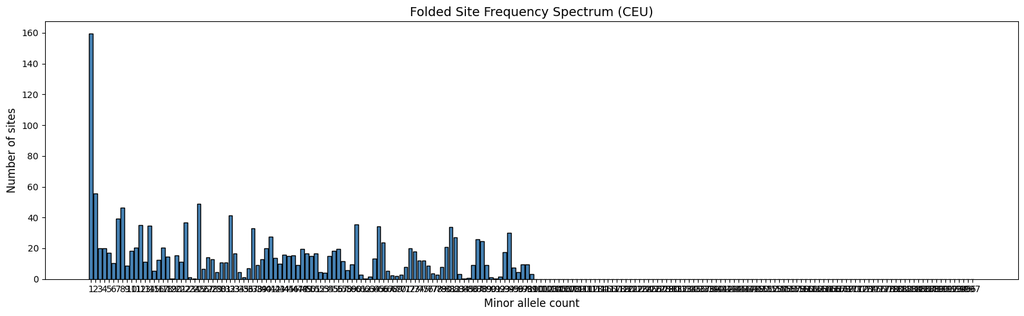

```python
import numpy as np
import matplotlib.pyplot as plt

# Set a wide figure size (Colab default cell width ≈ 16 inches of usable space)
plt.rcParams["figure.figsize"] = (16, 5)
plt.rcParams["figure.dpi"] = 100

# Load SFS
sfs = np.loadtxt("CEU.sfs")
sfs_trimmed = sfs[1:-1]

# Create the bar plot
plt.figure(figsize=(16, 5))
plt.bar(range(1, len(sfs_trimmed) + 1), sfs_trimmed,
        color="steelblue", edgecolor="black")
plt.xlabel("Minor allele count", fontsize=12)
plt.ylabel("Number of sites", fontsize=12)
plt.title("Folded Site Frequency Spectrum (CEU)", fontsize=14)
plt.xticks(range(1, len(sfs_trimmed) + 1))
plt.tight_layout()
plt.show()
```

Now we will convert the Site Allele Frequency (SAF) likelihoods into per-site estimates of nucleotide diversity (Theta) and neutrality statistics like Tajima's D. This step acts as the bridge between the raw genotype likelihoods (the .saf file) and the windowed summary statistics (the .pestPG file) that we will generate in the next step.

```python
# Step 3: Calculate Theta and Tajima's D
print("Calculate Theta and Tajima's D")
!realSFS saf2theta CEU.saf.idx -sfs CEU.sfs -outname CEU -P 8
```

[output not shown]

[output cut: 83 more lines]

```
	-> hello Im the master merge part of realSFS. and I'll now do a tripple bypass to find intersect
	-> 1) Will set iter according to chooseChr and start and stop, and possibly using -sites
	-> Writing 9049 sites for chr:7
	-> Only read nSites: 0 will therefore prepare next chromosome (or exit)
	-> Done reading data from chromosome will prepare next chromosome
	-> Is in multi sfs, will now read data from chr:9
	-> hello Im the master merge part of realSFS. and I'll now do a tripple bypass to find intersect
	-> 1) Will set iter according to chooseChr and start and stop, and possibly using -sites
	-> Writing 16982 sites for chr:8
	-> Only read nSites: 0 will therefore prepare next chromosome (or exit)
	-> Done reading data from chromosome will prepare next chromosome
	-> Writing 6445 sites for chr:9
	-> Output filenames:
		->"CEU.thetas.gz"
		->"CEU.thetas.idx"
```

This step produces two files:

- CEU.thetas.gz: A binary file containing per-site estimates. This is not human-readable and is used internally by the next tool (thetaStat).
- CEU.thetas.idx: An index file for the binary file. This is what you will feed into the next command.

Now we will calculate population genetic summary statistics (diversity and neutrality test statistics) within sliding windows across the genome using the per-site estimates from Step 3. It aggregates the per-site Theta values into windows of a specified size, allowing you to visualize how diversity and selection signals vary along chromosomes.

The thetaStat do_stat command reads the per-site estimates stored in CEU.thetas.idx and slides a window of 50,000 bp across the genome, moving in increments of 10,000 bp. Within each window, it sums the per-site Theta estimates and computes the final neutrality test statistics (including Tajima's D) .

This window-based approach is essential for:

- Detecting regional patterns of diversity and selection
- Smoothing noise from individual sites
- Comparing populations across genomic regions

The output file is "CEU.window_pi.pestPG", this is a tab-separated text file with 14 columns . The file is named CEU.window_pi.pestPG (the .pestPG extension is the standard output format from thetaStat).

```python
# Step 4: Sliding Window Stats (50kb windows, 10kb step)
print("Sliding Window Stats (50kb windows, 10kb step)")
!thetaStat do_stat CEU.thetas.idx -win 50000 -step 10000 -outnames CEU.window_pi

print("Single population analysis of CEU is complete.")
```

```
Sliding Window Stats (50kb windows, 10kb step)
 thetaStat do_stat CEU.thetas.idx -win 50000 -step 10000 -outnames CEU.window_pi
	Assuming binfile:CEU.thetas.gz and indexfile:CEU.thetas.idx
		Information from index file:
		0	1	11481	8	198
		1	10	10292	12773767285	198
		2	11	12100	25702957419	198
		3	12	7634	38418740193	198
		4	13	4700	48162685607	198
		5	14	4394	51159039069	198
		6	16	9076	57766484579	198
		7	17	1600	67332337753	198
		8	18	6433	70810240879	198
		9	19	1455	77166929053	198
		10	2	10067	80577588763	198
		11	20	11958	93622182392	198
		12	21	7907	106363324190	198
		13	22	3116	116065660796	198
		14	3	7810	119272936626	198
		15	4	6579	128992244727	198
		16	5	3299	135315447508	198
		17	6	9889	142076483121	198
		18	7	9049	151517050974	198
		19	8	16982	164675914955	198
		20	9	6445	183879617264	198
	 -r=(null) outnames=CEU.window_pi step: 10000 win: 50000
	pc.chr=1 pc.nSites=11481 firstpos=20017991 lastpos=20988856
	pc.chr=10 pc.nSites=10292 firstpos=20004688 lastpos=20994947
	pc.chr=11 pc.nSites=12100 firstpos=20009118 lastpos=20961024
	pc.chr=12 pc.nSites=7634 firstpos=20008757 lastpos=20986006
	pc.chr=13 pc.nSites=4700 firstpos=20147409 lastpos=20978606
	pc.chr=14 pc.nSites=4394 firstpos=20435699 lastpos=20957870
	pc.chr=16 pc.nSites=9076 firstpos=20019437 lastpos=20986610
	pc.chr=17 pc.nSites=1600 firstpos=20012247 lastpos=20927163
	pc.chr=18 pc.nSites=6433 firstpos=20015323 lastpos=20930094
	pc.chr=19 pc.nSites=1455 firstpos=20061445 lastpos=20978881
	pc.chr=2 pc.nSites=10067 firstpos=20016996 lastpos=20970153
	pc.chr=20 pc.nSites=11958 firstpos=20014848 lastpos=20997456
	pc.chr=21 pc.nSites=7907 firstpos=20023738 lastpos=20804380
	pc.chr=22 pc.nSites=3116 firstpos=20010623 lastpos=20983930
	pc.chr=3 pc.nSites=7810 firstpos=20003121 lastpos=20999923
	pc.chr=4 pc.nSites=6579 firstpos=20064980 lastpos=20995889
	pc.chr=5 pc.nSites=3299 firstpos=20115851 lastpos=20991505
	pc.chr=6 pc.nSites=9889 firstpos=20001820 lastpos=20954930
	pc.chr=7 pc.nSites=9049 firstpos=20006766 lastpos=20911315
	pc.chr=8 pc.nSites=16982 firstpos=20007911 lastpos=20999615
	pc.chr=9 pc.nSites=6445 firstpos=20000500 lastpos=20908614
	Dumping file: "CEU.window_pi.pestPG"
Single population analysis of CEU is complete.
```

Let us look inside the *.pestPG file and appreciate the reported enutrality test statistics for each genomic region (window).

```python
!head -5 /content/drive/MyDrive/PopGen_PopStructure/1000G/CEU.window_pi.pestPG
```

```
#(indexStart,indexStop)(firstPos_withData,lastPos_withData)(WinStart,WinStop)	Chr	WinCenter	tW	tP	tF	tH	tL	Tajima	fuf	fud	fayh	zeng	nSites
(310,1550)(20050756,20080964)(20020000,20070000)	1	20045000	2.381045	3.054615	2.241953	1.206889	2.130752	0.710969	0.393288	0.090481	0.413406	-0.047381	1240
(310,1550)(20050756,20080964)(20030000,20080000)	1	20055000	2.381045	3.054615	2.241953	1.206889	2.130752	0.710969	0.393288	0.090481	0.413406	-0.047381	1240
(310,1796)(20050756,20090000)(20040000,20090000)	1	20065000	2.932960	4.241126	2.356437	2.146801	3.193963	1.165412	0.792758	0.331188	0.384620	0.040753	1486
(310,2163)(20050756,20138334)(20050000,20100000)	1	20075000	4.170644	6.908049	2.510710	3.925314	5.416682	1.811314	1.442815	0.766505	0.390835	0.139736	1853
```

Now we will run analogous commands for the YRI African population.

```python
# --- YRI ---
print("Processing YRI...")
# Step 1: Calculate SAF likelihoods
!angsd -bam $YRI_BAMS -out YRI -GL 1 -doSaf 1 -anc $REF_ANC -minMapQ 30 -minQ 20 -nThreads 8

# Step 2: Estimate SFS (folded)
!realSFS YRI.saf.idx -fold 1 -P 8 > YRI.sfs

# Step 3: Calculate Theta and Tajima's D
!realSFS saf2theta YRI.saf.idx -sfs YRI.sfs -outname YRI -P 8

# Step 4: Sliding Window Stats (50kb windows, 10kb step)
!thetaStat do_stat YRI.thetas.idx -win 50000 -step 10000 -outnames YRI.window_pi

print("Single population analysis of YRI is complete.")
```

```
Processing YRI...
	-> angsd version: 0.940-dirty (htslib: 1.23.1) build(Dec 15 2024 09:11:59)
	-> angsd -bam 1000G_YRI_bam_list.txt -out YRI -GL 1 -doSaf 1 -anc anc.fa -minMapQ 30 -minQ 20 -nThreads 8
	-> Inputtype is BAM/CRAM
[multiReader] 108 samples in 108 input files
	-> Reading fasta: anc.fa
	-> Parsing 108 number of samples

	-> Allocated ~ 10 million nodes to the nodepool, this is not an estimate of the memory usage

	-> Allocated ~ 20 million nodes to the nodepool, this is not an estimate of the memory usage

	-> Allocated ~ 30 million nodes to the nodepool, this is not an estimate of the memory usage

	-> Allocated ~ 40 million nodes to the nodepool, this is not an estimate of the memory usage

	-> Allocated ~ 50 million nodes to the nodepool, this is not an estimate of the memory usage
	-> Printing at chr: 17 pos:20012246 chunknumber 200 contains 827 sites
	-> Done reading data waiting for calculations to finish
	-> Done waiting for threads
	-> Output filenames:
		->"YRI.arg"
		->"YRI.saf.gz"
		->"YRI.saf.pos.gz"
		->"YRI.saf.idx"
	-> Fri Oct  2 09:11:04 2026
	-> Arguments and parameters for all analysis are located in .arg file
	-> Total number of sites analyzed: 159038
	-> Number of sites retained after filtering: 158263
	[ALL done] cpu-time used =  78.93 sec
	[ALL done] walltime used =  194.00 sec
[persaf::persaf_init] Version of YRI.saf.idx is 3
[persaf::persaf_init] Assuming .saf.gz file is YRI.saf.gz
[persaf::persaf_init] Assuming .saf.pos.gz file is YRI.saf.pos.gz
	-> args: tole:0.000000 nthreads:8 maxiter:100 nsites(block):0 start:(null) chr:(null) start:-1 stop:-1 fstout:(null) oldout:0 seed:-1 bootstrap:0 resample_chr:0 whichFst:0 fold:1 ref:(null) anc:(null)
	-> The choice of -nSites will require atleast: 22.641483 megabyte memory, that is at least: 0.17% of total memory
	-> dim(YRI.saf.idx):217
	-> Dimension of parameter space: 217
	-> Done reading data from chromosome will prepare next chromosome
	-> Is in multi sfs, will now read data from chr:1
```

[output cut: 337 more lines]

```
	pc.chr=18 pc.nSites=6274 firstpos=20015326 lastpos=20930094
	pc.chr=19 pc.nSites=1410 firstpos=20061452 lastpos=20978881
	pc.chr=2 pc.nSites=9852 firstpos=20016997 lastpos=20970153
	pc.chr=20 pc.nSites=11638 firstpos=20014856 lastpos=20997455
	pc.chr=21 pc.nSites=7718 firstpos=20023742 lastpos=20804380
	pc.chr=22 pc.nSites=3012 firstpos=20010630 lastpos=20983930
	pc.chr=3 pc.nSites=7616 firstpos=20003129 lastpos=20999920
	pc.chr=4 pc.nSites=6427 firstpos=20064983 lastpos=20995889
	pc.chr=5 pc.nSites=3204 firstpos=20115853 lastpos=20991504
	pc.chr=6 pc.nSites=9624 firstpos=20001827 lastpos=20954926
	pc.chr=7 pc.nSites=8823 firstpos=20006768 lastpos=20911312
	pc.chr=8 pc.nSites=16649 firstpos=20007912 lastpos=20999614
	pc.chr=9 pc.nSites=6253 firstpos=20000493 lastpos=20908613
	Dumping file: "YRI.window_pi.pestPG"
Single population analysis of YRI is complete.
```

## Explanation of the ANGSD Commands

### Step 1: Calculate SAF Likelihoods

```
angsd -bam $CEU_BAMS -out CEU -GL 1 -doSaf 1 -anc $REF_ANC -minMapQ 30 -minQ 20 -nThreads 8
```

- -bam: Specifies the file containing the list of BAM files for the population.
- -out: The prefix for all output files (e.g., CEU.saf.gz, CEU.saf.idx).
- -GL 1: Specifies the genotype likelihood model. 1 is the SAMtools model, which is widely used and works well for most data.
- -doSaf 1: Tells ANGSD to compute the Site Allele Frequency (SAF) likelihoods. This is the first step in estimating the SFS.
- -anc: The ancestral reference genome. This is used to determine the ancestral state at each site.
- -minMapQ 30: Filters out reads with a mapping quality below 30. This removes ambiguously mapped reads.
- -minQ 20: Filters out bases with a base quality below 20. This removes low-quality base calls.
- -nThreads 8: Uses 8 threads for parallel processing.

Output: CEU.saf.idx, CEU.saf.gz, CEU.saf.pos.gz.

## Step 2: Estimate SFS

```
realSFS CEU.saf.idx -fold 1 -P 8 > CEU.sfs
```

- realSFS: The program within ANGSD that estimates the SFS from the SAF likelihoods.
- CEU.saf.idx: The index file from Step 1.
- -fold 1: Tells realSFS to use the folded SFS. This is used when the ancestral state is unknown or unreliable. If you have a reliable ancestral reference, you can omit this flag to get the unfolded SFS.
- -P 8: Uses 8 threads.
- > CEU.sfs: Redirects the output to a file called CEU.sfs.

Output: CEU.sfs (a text file containing the SFS).

## Step 3: Calculate Theta and Tajima's D

```
realSFS saf2theta CEU.saf.idx -sfs CEU.sfs -outname CEU -P 8
```

- saf2theta: A subcommand of realSFS that converts the SAF likelihoods and SFS into per-site estimates of θ and other statistics.
- -sfs CEU.sfs: The SFS file from Step 2.
- -outname CEU: The prefix for the output files (e.g., CEU.thetas.gz, CEU.thetas.idx).
- -P 8: Uses 8 threads.

Output: CEU.thetas.idx, CEU.thetas.gz.

## Step 4: Sliding Window Stats

```
thetaStat do_stat CEU.thetas.idx -win 50000 -step 10000 -outnames CEU.window_pi
```

- thetaStat: A program that summarizes the per-site theta estimates into windows.
- do_stat: The subcommand to calculate statistics.
- -win 50000: The window size in base pairs (50 kb).
- -step 10000: The step size in base pairs (10 kb). This means windows overlap by 40 kb.
- -outnames CEU.window_pi: The prefix for the output files.

Output: CEU.window_pi.pestPG (a text file with per-window statistics).

## What is in the .pestPG file?

The .pestPG file contains the following columns:

- Region/Chromosome
- Window Center
- Watterson's Theta (θ<sub>w</sub>)
- Pairwise Theta (θ<sub>π</sub>) - This is your Nucleotide Diversity
- Tajima's D
- Fu & Li's F
- Fu & Li's D
- Fay's H
- Zeng's E
- Number of Sites

To compute an unfolded SFS, you need to know which allele is ancestral and which is derived. Without an outgroup, you can only calculate a folded SFS (minor allele frequency), which loses information about the direction of allele frequency changes .

By using the chimp genome as an outgroup, you can polarize the alleles . This polarization is crucial for downstream analyses like the Population Branch Statistic (PBS) or specific selection scans that require directional information (e.g., detecting a selective sweep where the derived allele rises to high frequency)

## 6. Visualization of Single Population Statistics

We will now use R to plot the SFS and the sliding window statistics. The `.pestPG` file (produced by `thetaStat`) contains the per-window statistics.

### Interpretation of Plots

**SFS Plot**:

- A typical neutral population has an "L-shaped" SFS, meaning most sites are rare alleles (low frequency).
- If the curve is flattened, it suggests an excess of intermediate-frequency alleles (e.g., due to a bottleneck).

**Nucleotide Diversity (π) Plot**:

- Higher π indicates higher genetic diversity.
- Regions with low π (valleys) may indicate selective sweeps.
- Regions with high π (peaks) may indicate balancing selection or low recombination.

**Tajima's D Plot**:

- Look for windows where the dashed line (D=0) is crossed.
- A consistently negative D across the genome suggests population expansion.
- A sharply negative D in a specific region suggests a selective sweep.
- A consistently positive D suggests a population bottleneck or balancing selection.

```python
%%writefile plot_single_pop.R
# =============================================================
# Manhattan-style plots for Pi and Tajima's D
# =============================================================

library(ggplot2)
library(dplyr)

setwd("/content/drive/MyDrive/PopGen_PopStructure/1000G")

# -------------------------------------------------------------
# Helper: build Manhattan-style data frame with cumulative offset
# -------------------------------------------------------------
make_manhattan <- function(df, value_col, pop_name) {
  df <- df[, c("Chr", "WinCenter", value_col)]
  colnames(df) <- c("Chr", "Mid", "Value")
  df$Pop <- pop_name

  # Keep only valid chromosomes (1-22), coerce Chr to numeric
  df$Chr <- suppressWarnings(as.numeric(as.character(df$Chr)))
  df <- df[!is.na(df$Chr) & df$Chr %in% 1:22, ]
  df <- df[order(df$Chr, df$Mid), ]

  # Per-chromosome max position
  chr_len <- df %>%
    group_by(Chr) %>%
    summarise(len = max(Mid, na.rm = TRUE), .groups = "drop") %>%
    arrange(Chr)

  # Cumulative offset: chr1 starts at 0, chr2 starts after chr1, etc.
  chr_len$offset <- c(0, head(cumsum(chr_len$len), -1))
  chr_len$center <- chr_len$offset + chr_len$len / 2

  # Join offsets back
  df <- df %>% left_join(chr_len[, c("Chr", "offset", "center")], by = "Chr")
  df$Position <- df$Mid + df$offset
  df
}

# -------------------------------------------------------------
# Load pestPG files
# -------------------------------------------------------------
ceu_pi <- read.table("CEU.window_pi.pestPG", header = TRUE, sep = "\t",
                     comment.char = "")
yri_pi <- read.table("YRI.window_pi.pestPG", header = TRUE, sep = "\t",
                     comment.char = "")

# Per-site nucleotide diversity
ceu_pi$Pi <- ceu_pi$tP / ceu_pi$nSites
yri_pi$Pi <- yri_pi$tP / yri_pi$nSites

# -------------------------------------------------------------
# Plot 1: Nucleotide Diversity (Pi)
# -------------------------------------------------------------
pi_ceu <- make_manhattan(ceu_pi, "Pi", "CEU")
pi_yri <- make_manhattan(yri_pi, "Pi", "YRI")
pi_df  <- rbind(pi_ceu, pi_yri)

# After building pi_df
library(dplyr)
pi_df %>%
  group_by(Chr) %>%
  summarise(min_pos = min(Position), max_pos = max(Position),
            n = n(), .groups = "drop") %>%
  print(n = 25)

# Chromosome color key + axis breaks
chr_key <- pi_df %>%
  distinct(Chr, center) %>%
  arrange(Chr) %>%
  mutate(color = rep(c("black", "grey55"), length.out = n()))

p_pi <- ggplot(pi_df, aes(x = Position, y = Value, color = factor(Chr))) +
  geom_point(size = 0.6, alpha = 0.7) +
  scale_color_manual(values = setNames(chr_key$color, chr_key$Chr)) +
  scale_x_continuous(breaks = chr_key$center, labels = chr_key$Chr,
                     expand = c(0.01, 0)) +
  facet_grid(Pop ~ ., scales = "free_y") +
  theme_bw() +
  theme(legend.position = "none",
        panel.grid.minor.x = element_blank(),
        panel.grid.major.x = element_blank()) +
  labs(title = "Nucleotide Diversity (Pi) in Sliding Windows",
       x = "Chromosome",
       y = "Nucleotide Diversity (pi)")

ggsave("Pi_plot.pdf", p_pi, width = 14, height = 7)
ggsave("Pi_plot.png", p_pi, width = 14, height = 7, dpi = 120)

# -------------------------------------------------------------
# Plot 2: Tajima's D
# -------------------------------------------------------------
taj_ceu <- make_manhattan(ceu_pi, "Tajima", "CEU")
taj_yri <- make_manhattan(yri_pi, "Tajima", "YRI")
taj_df  <- rbind(taj_ceu, taj_yri)

chr_key_taj <- taj_df %>%
  distinct(Chr, center) %>%
  arrange(Chr) %>%
  mutate(color = rep(c("black", "grey55"), length.out = n()))

p_taj <- ggplot(taj_df, aes(x = Position, y = Value, color = factor(Chr))) +
  geom_point(size = 0.6, alpha = 0.7) +
  geom_hline(yintercept = 0, linetype = "dashed", color = "red") +
  scale_color_manual(values = setNames(chr_key_taj$color, chr_key_taj$Chr)) +
  scale_x_continuous(breaks = chr_key_taj$center, labels = chr_key_taj$Chr,
                     expand = c(0.01, 0)) +
  facet_grid(Pop ~ ., scales = "free_y") +
  theme_bw() +
  theme(legend.position = "none",
        panel.grid.minor.x = element_blank(),
        panel.grid.major.x = element_blank()) +
  labs(title = "Tajima's D in Sliding Windows",
       x = "Chromosome",
       y = "Tajima's D")

ggsave("TajimaD_plot.pdf", p_taj, width = 14, height = 7)
ggsave("TajimaD_plot.png", p_taj, width = 14, height = 7, dpi = 120)

cat("Manhattan-style plots generated.\n")
```

```
Overwriting plot_single_pop.R
```

This R script requires a few R packages to be installed via conda.

```python
!conda install -y -c conda-forge r-base r-ggplot2 r-reshape2 r-dplyr
```

```
Channels:
 - conda-forge
Platform: linux-64
Solving environment: | / done

# All requested packages already installed.
```

```python
!Rscript plot_single_pop.R
```

```
# A tibble: 21 × 4
     Chr   min_pos   max_pos     n
   <dbl>     <dbl>     <dbl> <int>
 1     1  20045000  20955000   184
 2     2  41000000  41900000   182
 3     3  61935000  62865000   188
 4     4  82960000  83830000   176
 5     5 103975000 104795000   166
 6     6 124830000 125720000   180
 7     7 145755000 146605000   172
 8     8 166640000 167570000   188
 9     9 187605000 188445000   170
10    10 208480000 209410000   188
11    11 229445000 230345000   182
12    12 250380000 251300000   186
13    13 271475000 272245000   156
14    14 292710000 293170000    94
15    16 313215000 314125000   184
16    17 334170000 335020000   172
17    18 355065000 355925000   174
18    19 376020000 376870000   172
19    20 396915000 397835000   186
20    21 417890000 418610000   146
21    22 438655000 439565000   184
Warning message:
Removed 1032 rows containing missing values or values outside the scale range
(`geom_point()`).
Warning message:
Removed 1032 rows containing missing values or values outside the scale range
(`geom_point()`).
Manhattan-style plots generated.
```

```
=== Site Frequency Spectrum ===
```

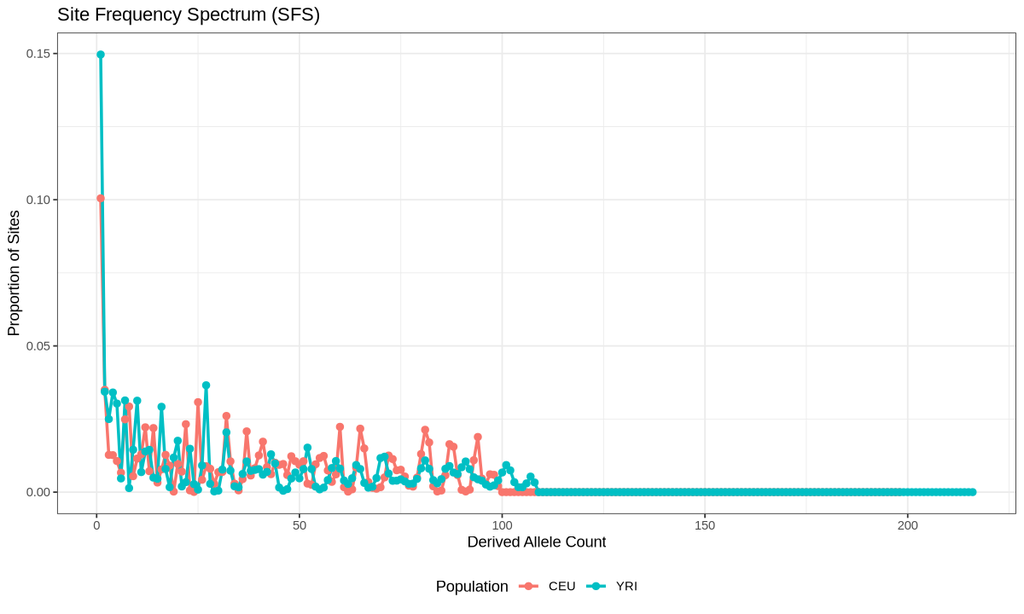

```python
from IPython.display import Image, display

print("=== Site Frequency Spectrum ===")
display(Image(filename="SFS_plot.png"))
```

The SFS shows a strong excess of low-frequency variants in both populations, indicating that most segregating variants occur at relatively low frequency. Such an excess can arise under recent population expansion and/or other demographic processes that generate an abundance of rare alleles.

```
=== Nucleotide Diversity (Pi) ===
```

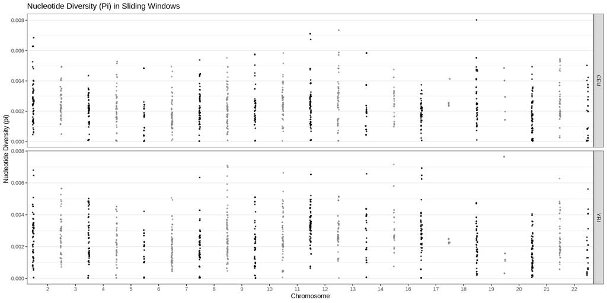

```python
from IPython.display import Image, display

print("\n=== Nucleotide Diversity (Pi) ===")
display(Image(filename="Pi_plot.png"))
```

Genetic diversity is heterogeneous along the genome, with regions of relatively high and low nucleotide diversity. Regions with reduced π may reflect demographic history, background selection, selective sweeps, or other processes affecting local genetic variation.

```
=== Tajima's D ===
```

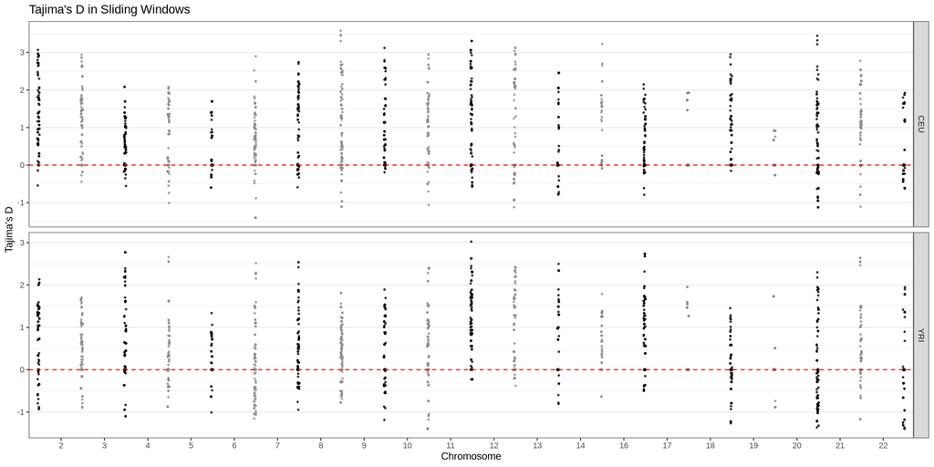

```python
from IPython.display import Image, display

print("\n=== Tajima's D ===")
display(Image(filename="TajimaD_plot.png"))
```

A positive Tajima's D means that there are more intermediate-frequency variants relative to rare variants than expected under the standard neutral equilibrium model.

Possible explanations include:

- balancing selection,
- population subdivision/structure,
- a recent population contraction or bottleneck,
- or other departures from the standard neutral demographic model.

Again, positive Tajima's D does not by itself prove balancing selection. Demographic history can produce the same pattern.

## 7. Between Population Analysis (F<sub>ST</sub>)

We now compare the CEU and YRI populations to see how genetically distinct they are. **F<sub>ST</sub>** is a measure of population differentiation due to population structure. It represents the proportion of genetic variance that is between populations relative to the total variance.

$$F_{ST} = \frac{\pi_{between} - \pi_{within}}{\pi_{between}}$$

**Interpretation**:

- **F<sub>ST</sub> = 0**: Populations are identical (panmixia).
- **F<sub>ST</sub> = 1**: Populations are completely differentiated.
- **High F<sub>ST</sub> peaks**: Often correspond to regions of **local adaptation** or **selective sweeps**.

### The 2D-SFS

To compute F<sub>ST</sub>, we first need to estimate the joint Site Frequency Spectrum (2D-SFS) for the two populations. This is a matrix where the entry ((i, j)) represents the number of sites where the derived allele is at frequency (i) in population 1 and frequency (j) in population 2. ANGSD uses this 2D-SFS to compute F<sub>ST</sub>.

```python
#@title 7.1 Compute F_ST Between CEU and YRI { display-mode: "form" }

print("Computing 2D-SFS for CEU vs YRI...")
# Step 1: Compute 2D-SFS
!realSFS CEU.saf.idx YRI.saf.idx > CEU.YRI.ml

print("Indexing F_ST data...")
# Step 2: Index the F_ST data
!realSFS fst index CEU.saf.idx YRI.saf.idx -sfs CEU.YRI.ml -fstout CEU_YRI

print("Calculating global F_ST...")
# Step 3: Calculate Global F_ST
!realSFS fst stats CEU_YRI.fst.idx

print("Calculating sliding window F_ST...")
# Step 4: Calculate Sliding Window F_ST (50kb windows, 10kb step)
!realSFS fst stats2 CEU_YRI.fst.idx -win 50000 -step 10000 > slidingwindow_win50_step10

print("F_ST analysis complete.")
```

[output not shown]

[output cut: 474 more lines]

```
nSites:1563
nSites:6268
nSites:1406
nSites:9842
nSites:11623
nSites:7711
nSites:3012
nSites:7597
nSites:6420
nSites:3202
nSites:9608
nSites:8817
nSites:16604
nSites:6241
F_ST analysis complete.
```

## Explanation of the F_ST Commands

### Step 1: Compute 2D-SFS

```
realSFS CEU.saf.idx YRI.saf.idx > CEU.YRI.ml
```

- realSFS: Estimates the joint SFS from the SAF likelihoods of two populations.
- CEU.saf.idx YRI.saf.idx: The index files for the two populations.
- > CEU.YRI.ml: Redirects the output to a file called CEU.YRI.ml. This file contains the 2D-SFS matrix.

Output: CEU.YRI.ml (a text file containing the 2D-SFS).

## Step 2: Index the F_ST Data

```
realSFS fst index CEU.saf.idx YRI.saf.idx -sfs CEU.YRI.ml -fstout CEU_YRI
```

- fst index: Prepares the data for F<sub>ST</sub> calculation.
- -sfs CEU.YRI.ml: The 2D-SFS file from Step 1.
- -fstout CEU_YRI: The prefix for the output files.

Output: CEU_YRI.fst.idx, CEU_YRI.fst.gz.

## Step 3: Calculate Global F_ST

```
realSFS fst stats CEU_YRI.fst.idx
```

- fst stats: Calculates the global (genome-wide) F<sub>ST</sub>.

Output: Prints the global F<sub>ST</sub> values (unweighted and weighted) to the console.

## Step 4: Calculate Sliding Window F_ST

```
realSFS fst stats2 CEU_YRI.fst.idx -win 50000 -step 10000 > slidingwindow_win50_step10
```

- fst stats2: Calculates F<sub>ST</sub> in windows.
- -win 50000: Window size (50 kb).
- -step 10000: Step size (10 kb).
- > slidingwindow_win50_step10: Redirects the output to a file.

Output: slidingwindow_win50_step10 (a text file with per-window F<sub>ST</sub> values).

```python
%%writefile plot_fst.R
# =============================================================
# F_ST Landscape Plot (per-chromosome style, matching the slide)
# =============================================================

# Set working directory
setwd("/content/drive/MyDrive/PopGen_PopStructure/1000G")

# -------------------------------------------------------------
# 1. Read the file exactly like in the slide
# -------------------------------------------------------------
# The slide reads the file with read.delim and no header
df <- read.delim("slidingwindow_win50_step10", header = FALSE)

# The slide then removes the first row (the header line)
# because realSFS fst stats2 writes a header that read.delim keeps as data
df <- df[-1, ]

# -------------------------------------------------------------
# 2. Convert the relevant columns to numeric
# -------------------------------------------------------------
# Column structure in the file:
#   V1 = region string (ignored)
#   V2 = chromosome
#   V3 = window midpoint
#   V4 = number of sites
#   V5 = Fst value
df$V2 <- as.numeric(df$V2)   # chromosome
df$V3 <- as.numeric(df$V3)   # midpoint
df$V5 <- as.numeric(df$V5)   # Fst

# -------------------------------------------------------------
# 3. Order by chromosome and midpoint
# -------------------------------------------------------------
df <- df[order(df$V2, df$V3), ]
rownames(df) <- seq(1, dim(df)[1], 1)

# -------------------------------------------------------------
# 4. Plot exactly as in the slide
# -------------------------------------------------------------
# Open a PNG device for saving (and later display in Colab)
png("Fst_plot.png", width = 1400, height = 800, res = 120)

# The slide uses base R plot()
#   - x-axis: the row index (i.e., sequential position across all windows)
#   - y-axis: Fst values
#   - color:  chromosome number (so each chromosome gets its own color)
#   - xaxt="n": suppress automatic x-axis ticks (we add custom ones)
plot(df$V5,
     col  = df$V2,
     xlab = "Chromosomes",
     ylab = "Fst",
     xaxt = "n",
     pch  = 20,
     cex  = 0.6,
     main = "Genome-wide Fst (CEU vs YRI)")

# Find the row index of the first window of each chromosome
# These are the positions where we put the chromosome labels
myticks <- as.numeric(rownames(df[!duplicated(df$V2), ]))

# Add custom x-axis with chromosome numbers 1..21
axis(side = 1, at = myticks, labels = seq(1, 21, 1), cex.axis = 0.8)

# Optional: add a horizontal line at the genome-wide mean
abline(h = mean(df$V5, na.rm = TRUE), col = "red", lty = 2, lwd = 1.5)

dev.off()

# Also save a PDF version for high-quality printing
pdf("Fst_plot.pdf", width = 14, height = 8)
plot(df$V5,
     col  = df$V2,
     xlab = "Chromosomes",
     ylab = "Fst",
     xaxt = "n",
     pch  = 20,
     cex  = 0.6,
     main = "Genome-wide Fst (CEU vs YRI)")
myticks <- as.numeric(rownames(df[!duplicated(df$V2), ]))
axis(side = 1, at = myticks, labels = seq(1, 21, 1), cex.axis = 0.8)
abline(h = mean(df$V5, na.rm = TRUE), col = "red", lty = 2, lwd = 1.5)
dev.off()

cat("F_ST plot has been generated in the slide's style.\n")
cat("Number of windows plotted:", nrow(df), "\n")
cat("Number of chromosomes:", length(unique(df$V2)), "\n")
cat("Mean Fst:", round(mean(df$V5, na.rm = TRUE), 4), "\n")
```

```
Overwriting plot_fst.R
```

```python
!Rscript plot_fst.R
```

```
Fontconfig warning: using without calling FcInit()
null device
          1
null device
          1
F_ST plot has been generated in the slide's style.
Number of windows plotted: 1299
Number of chromosomes: 21
Mean Fst: 0.1325
```

```
=== Genome-wide F_ST (CEU vs YRI) ===
```

[figure not shown]

```python
from IPython.display import Image, display

print("=== Genome-wide F_ST (CEU vs YRI) ===")
display(Image(filename="Fst_plot.png"))
```

## 8. Final Discussion and Interpretation

### 8.1 Ancestral Reference

The commands use `anc.fa` (the chimp reference). This is standard practice for human population genetics. By using the chimp genome as an outgroup, you can infer the **ancestral state** at each site. If you don't have an outgroup, you must use a "folded" SFS (`-fold 1`), which assumes you don't know which allele is ancestral and which is derived. Using an ancestral reference (like chimp) allows you to use an "unfolded" SFS, which gives more power to detect selection.

### 8.2 Tajima's D & Demography

- If your Tajima's D is significantly **negative** across the genome, it indicates an **excess of rare variants**. This is a signature of a recent **population expansion** (common in human populations like YRI) or **purifying selection**.
- If it is significantly **positive**, it indicates an **excess of intermediate-frequency variants**, which can be caused by a **population bottleneck** or **balancing selection**.

### 8.3 F<sub>ST</sub> & Population Structure

- High F<sub>ST</sub> peaks (values close to 0.5 or higher) in the sliding window plot often correspond to regions of **local adaptation** or **selective sweeps**. For example, the *LCT* gene region often shows high F<sub>ST</sub> between European and African populations due to lactase persistence.
- Overall low F<sub>ST</sub> (e.g., 0.1-0.15) suggests that most of the genome is shared, but specific regions show high differentiation.

### 8.4 Neutral vs. Selection

- **Neutral Evolution**: Characterized by Tajima's D ≈ 0 and low F<sub>ST</sub> variance.
- **Selection**: Characterized by extreme Tajima's D (negative for sweeps, positive for balancing) and high F<sub>ST</sub> peaks.

### 8.5 Further Exploration

- Try changing the window size and step in the sliding window analysis to see how it affects the resolution of your plots.
- Compute F<sub>ST</sub> between other population pairs (e.g., CEU vs. CHB) to see different patterns of differentiation.
- Use the unfolded SFS (if you have a reliable ancestral reference) to get more precise estimates of Tajima's D.

## 9. Summary

In this notebook we:

✅ Installed **Conda** and **ANGSD** in Google Colab.  
✅ Mounted **Google Drive** to access the 1000 Genomes BAM files.  
✅ Computed **SAF likelihoods** for the CEU and YRI populations separately.  
✅ Estimated the **Site Frequency Spectrum (SFS)** for each population.  
✅ Calculated **Nucleotide Diversity (π)** and **Tajima's D** in sliding windows.  
✅ Visualized the SFS, π, and Tajima's D as landscape plots in R.  
✅ Computed the joint **2D-SFS** and estimated **F<sub>ST</sub>** globally and in sliding windows.  
✅ Visualized F<sub>ST</sub> as a landscape plot.  
✅ Discussed the interpretation of Tajima's D and F<sub>ST</sub> in the context of selection, population expansion, and bottlenecks.

### References

- Korneliussen, T. S., Albrechtsen, A., & Nielsen, R. (2014). *ANGSD: Analysis of Next Generation Sequencing Data.* BMC Bioinformatics.
- Tajima, F. (1989). *Statistical method for testing the neutral mutation hypothesis by DNA polymorphism.* Genetics.
- Weir, B. S., & Cockerham, C. C. (1984). *Estimating F-statistics for the analysis of population structure.* Evolution.

## 10. Render the Notebook as HTML

We now export this notebook to a standalone HTML file using `nbconvert`. The HTML includes all markdown, code, and outputs (including the inline figures), so it can be shared with students who do not use Colab.

```python
# ------------------------------------------------------------------
# 10. Convert this notebook to HTML as the last step
# ------------------------------------------------------------------
import os

# ----- 1. Ask Colab to save the current notebook to Drive -----------
from google.colab import _message

# Path where the notebook is saved (change if you want a different location)
notebook_path = "/content/drive/MyDrive/PopGen_PopStructure/PopGen_Diversity_TajimaD_Fst.ipynb"
html_path     = notebook_path.replace(".ipynb", ".html")

# Ask Colab to save the current notebook (same as File -> Save)
_message.blocking_request(
    "save_notebook",
    request={},
    timeout_sec=5,
)

print("Notebook saved by Colab to its default Drive location.")
print("Assuming the notebook path is:", notebook_path)
```

```
Notebook saved by Colab to its default Drive location.
Assuming the notebook path is: /content/drive/MyDrive/PopGen_PopStructure/PopGen_Diversity_TajimaD_Fst.ipynb
```

```python
# ----- 2. Run nbconvert -------------------------------------------
# Convert the notebook on disk to a standalone HTML file.
!jupyter nbconvert --to html /content/drive/MyDrive/PopGen_PopStructure/Fst_Colab.ipynb
```

```
[NbConvertApp] Converting notebook /content/drive/MyDrive/PopGen_PopStructure/Fst_Colab.ipynb to html
[NbConvertApp] WARNING | Alternative text is missing on 4 image(s).
[NbConvertApp] Writing 1384338 bytes to /content/drive/MyDrive/PopGen_PopStructure/Fst_Colab.html
```